# Differential Expression

2018-02-14

```r
# Last modified 2017-12-14
library(DESeq2)
library(bcbioRNASeq)

# Shared R Markdown settings
prepareRNASeqTemplate()
if (file.exists("_setup.R")) {
    source("_setup.R")
}

# Directory paths
dataDir <- file.path(params$outputDir, "data", Sys.Date())
countsDir <- file.path(params$outputDir, "results", Sys.Date(), "counts")
deDir <- file.path(params$outputDir, "results", Sys.Date(), "differential_expression")
invisible(mapply(
    list(dataDir, countsDir, deDir),
    FUN = dir.create,
    MoreArgs = list(recursive = TRUE, showWarnings = FALSE)
))

# Load bcbioRNASeq object
bcbName <- load(params$bcbFile)
bcb <- get(bcbName, inherits = FALSE)
```

# Overview

```r
> dds <- bcbio(bcb, "DESeqDataSet")
> design(dds) <- params$design
> dds <- DESeq(dds)
> rld <- rlog(dds)
```

# Alpha level (FDR) cutoffs

Let’s take a look at the number of genes we get with different false discovery rate (FDR) cutoffs. These tests subset *P* values that have been multiple test corrected using the Benjamini Hochberg (BH) method (Benjamini and Hochberg 1995).

```r
> alphaSummary(dds)
```

|  | 0.1 | 0.05 | 0.01 | 0.001 | 1e-06 |
| --- | --- | --- | --- | --- | --- |
| LFC > 0 (up) | 179, 0.61% | 142, 0.48% | 93, 0.32% | 58, 0.2% | 25, 0.085% |
| LFC < 0 (down) | 140, 0.48% | 104, 0.35% | 58, 0.2% | 38, 0.13% | 15, 0.051% |
| outliers | 0, 0% | 0, 0% | 0, 0% | 0, 0% | 0, 0% |
| low counts | 11599, 39% | 11046, 38% | 11046, 38% | 10494, 36% | 16570, 56% |
| cutoff | (mean count < 7) | (mean count < 6) | (mean count < 6) | (mean count < 5) | (mean count < 74) |

# Results

```r
> # help("results", "DESeq2")
> # For contrast argument as character vector:
> #   1. Design matrix factor of interest.
> #   2. Numerator for LFC (expt).
> #   3. Denominator for LFC (control).
> resUnshrunken <- results(
+     dds,
+     contrast = params$contrast,
+     alpha = params$alpha)
>
> # DESeqResults with shrunken log2 fold changes (LFC)
> # help("lfcShrink", "DESeq2")
> # Only `coef` or `contrast` can be specified, not both
> # Use the correct `coef` number to modify from `resultsNames(dds)`
> resShrunken <- lfcShrink(
+     dds = dds,
+     # coef = 2,
+     contrast = params$contrast,
+     res = resUnshrunken)
>
> # Use shrunken LFC values by default
> res <- resShrunken
> saveData(res, dir = dataDir)
```

We performed the analysis using a BH adjusted *P* value cutoff of 0.01 and a log fold-change (LFC) ratio cutoff of 1.

# Plots

## Mean average (MA)

An MA plot compares transformed counts on `M` (log ratio) and `A` (mean average) scales (Y. H. Yang et al. 2002).

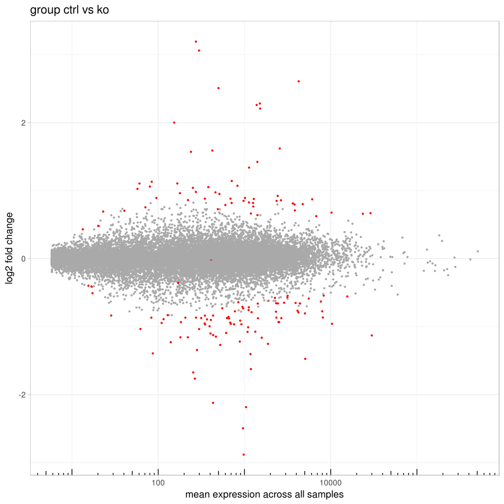

```r
> plotMA(res)
```

## Volcano

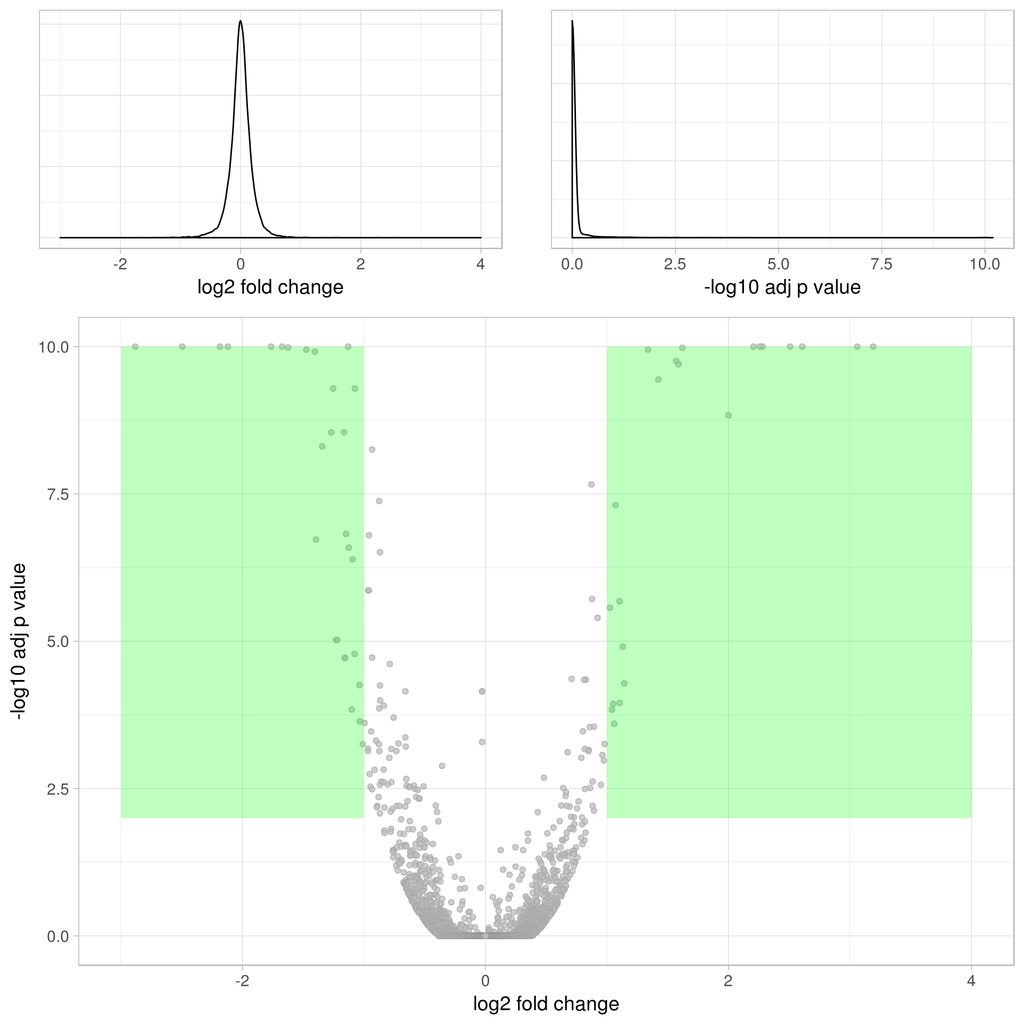

```r
> plotVolcano(res, lfc = params$lfc)
```

## Heatmap

This plot shows only differentially expressed genes on a per-sample basis. We have scaled the data by row and used the `ward.D2` method for clustering (Ward 1963).

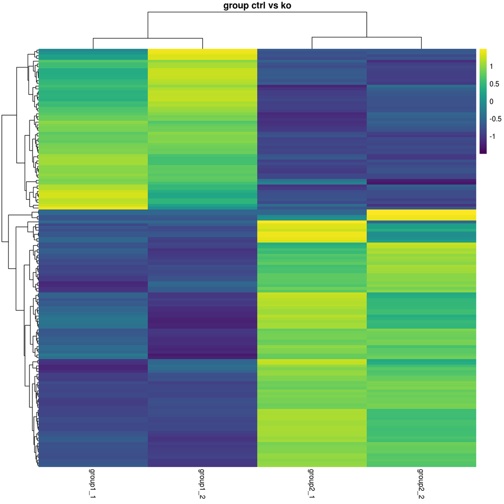

```r
> plotDEGHeatmap(res, counts = rld)
```

# File downloads

The results are saved as gzip-compressed comma separated values (CSV). Gzip compression is natively supported on [macOS](https://www.apple.com/macos) and Linux-based operating systems. If you’re running Windows, we recommend installing [7-Zip](http://www.7-zip.org). CSV files can be opened in [Excel](https://products.office.com/en-us/excel) or [RStudio](https://www.rstudio.com).

## Count matrices

- `normalizedCounts.csv.gz`: Use to evaluate individual genes and/or generate plots. These counts are normalized for the variation in sequencing depth across samples.
- `tpm.csv.gz`: Transcripts per million, scaled by length and also suitable for plotting.
- `rawCounts.csv.gz`: Only use to perform a new differential expression analysis. These counts will vary across samples due to differences in sequencing depth, and have not been normalized. Do not use this file for plotting genes.

## Differentially expressed genes (DEG)

```r
> resTbl <- resultsTables(res, lfc = params$lfc, write = TRUE, summary = TRUE,
+     headerLevel = 3, dir = deDir)
```

Summary statistics: - 47729 genes in counts matrix - Base mean > 0: 29451 genes (non-zero) - Base mean > 1: 23567 genes - Alpha cutoff: 0.01 - LFC cutoff: 1 (applied in tables only) - DEG pass alpha: 151 genes - DEG LFC up: 22 genes - DEG LFC down: 28 genes

DEG tables are sorted by BH-adjusted P value, and contain the following columns:

- `ensgene`: [Ensembl](http://useast.ensembl.org) gene identifier.
- `baseMean`: Mean of the normalized counts per gene for all samples.
- `log2FoldChange`: log2 fold change.
- `lfcSE`: log2 standard error.
- `stat`: Wald statistic.
- `pvalue`: Walt test *P* value.
- `padj`: BH adjusted Wald test *P* value (corrected for multiple comparisons; aka FDR).
- `externalGeneName`: [Ensembl](http://useast.ensembl.org) name (a.k.a. symbol).
- `description`: [Ensembl](http://useast.ensembl.org) description.
- `geneBiotype`: [Ensembl](http://useast.ensembl.org) biotype (e.g. `protein_coding`).

# Top tables

```r
> topTables(resTbl)
```

group ctrl vs ko (upregulated)

| ensgene | baseMean | lfc | padj | symbol | description |
| --- | --- | --- | --- | --- | --- |
| ENSMUSG00000052974 | 4250 | 2.61 | 2.38e-48 | Cyp2f2 | cytochrome P450, family 2, subfamily f, polypeptide 2 |
| ENSMUSG00000059824 | 1509 | 2.28 | 9.62e-46 | Dbp | D site albumin promoter binding protein |
| ENSMUSG00000066258 | 298 | 3.06 | 2.06e-40 | Trim12a | tripartite motif-containing 12A |
| ENSMUSG00000028358 | 500 | 2.51 | 1.29e-38 | Zfp618 | zinc finger protein 618 |
| ENSMUSG00000057596 | 274 | 3.19 | 1.29e-38 | Trim30d | tripartite motif-containing 30D |
| ENSMUSG00000021775 | 1518 | 2.21 | 2.31e-36 | Nr1d2 | nuclear receptor subfamily 1, group D, member 2 |
| ENSMUSG00000020889 | 1385 | 2.26 | 1.56e-25 | Nr1d1 | nuclear receptor subfamily 1, group D, member 1 |
| ENSMUSG00000032281 | 2568 | 1.62 | 4.72e-12 | Acsbg1 | acyl-CoA synthetase bubblegum family member 1 |
| ENSMUSG00000049892 | 1131 | 1.34 | 1.28e-11 | Rasd1 | RAS, dexamethasone-induced 1 |
| ENSMUSG00000040896 | 240 | 1.57 | 7.56e-11 | Kcnd3 | potassium voltage-gated channel, Shal-related family, member 3 |
| ENSMUSG00000001864 | 424 | 1.59 | 9.97e-11 | Aif1l | allograft inflammatory factor 1-like |
| ENSMUSG00000017969 | 1412 | 1.42 | 2.62e-10 | Ptgis | prostaglandin I2 (prostacyclin) synthase |
| ENSMUSG00000045868 | 153 | 2.00 | 1.37e-09 | Gvin1 | GTPase, very large interferon inducible 1 |
| ENSMUSG00000035357 | 829 | 1.07 | 4.89e-08 | Pdzrn3 | PDZ domain containing RING finger 3 |
| ENSMUSG00000029306 | 61 | 1.10 | 2.10e-06 | Ibsp | integrin binding sialoprotein |
| ENSMUSG00000096972 | 57 | 1.02 | 2.70e-06 | Gm26883 | predicted gene, 26883 |
| ENSMUSG00000007682 | 84 | 1.13 | 1.24e-05 | Dio2 | deiodinase, iodothyronine, type II |
| ENSMUSG00000035686 | 712 | 1.14 | 5.22e-05 | Thrsp | thyroid hormone responsive |
| ENSMUSG00000030256 | 166 | 1.11 | 1.11e-04 | Bhlhe41 | basic helix-loop-helix family, member e41 |
| ENSMUSG00000002633 | 381 | 1.05 | 1.15e-04 | Shh | sonic hedgehog |
| ENSMUSG00000001665 | 252 | 1.04 | 1.45e-04 | Gstt3 | glutathione S-transferase, theta 3 |
| ENSMUSG00000060441 | 80 | 1.06 | 2.52e-04 | Trim5 | tripartite motif-containing 5 |

group ctrl vs ko (downregulated)

| ensgene | baseMean | lfc | padj | symbol | description |
| --- | --- | --- | --- | --- | --- |
| ENSMUSG00000020038 | 962 | -2.49 | 4.37e-51 | Cry1 | cryptochrome 1 (photolyase-like) |
| ENSMUSG00000026442 | 980 | -2.88 | 8.45e-40 | Nfasc | neurofascin |
| ENSMUSG00000026077 | 1043 | -2.18 | 5.01e-25 | Npas2 | neuronal PAS domain protein 2 |
| ENSMUSG00000029757 | 432 | -2.12 | 1.40e-21 | Dync1i1 | dynein cytoplasmic 1 intermediate chain 1 |
| ENSMUSG00000027712 | 30000 | -1.13 | 8.95e-15 | Anxa5 | annexin A5 |
| ENSMUSG00000029108 | 266 | -1.76 | 9.39e-15 | Pcdh7 | protocadherin 7 |
| ENSMUSG00000102802 | 255 | -1.67 | 1.95e-13 | Mgam2-ps | maltase-glucoamylase 2, pseudogene |
| ENSMUSG00000022790 | 1189 | -1.62 | 3.57e-12 | Igsf11 | immunoglobulin superfamily, member 11 |
| ENSMUSG00000053279 | 5065 | -1.47 | 1.26e-11 | Aldh1a1 | aldehyde dehydrogenase family 1, subfamily A1 |
| ENSMUSG00000023959 | 1175 | -1.40 | 2.22e-11 | Clic5 | chloride intracellular channel 5 |
| ENSMUSG00000028150 | 1336 | -1.07 | 4.15e-10 | Rorc | RAR-related orphan receptor gamma |
| ENSMUSG00000050447 | 1872 | -1.25 | 4.15e-10 | Lypd6 | LY6/PLAUR domain containing 6 |
| ENSMUSG00000051359 | 1588 | -1.16 | 2.73e-09 | Ncald | neurocalcin delta |
| ENSMUSG00000060044 | 523 | -1.27 | 2.76e-09 | Tmem26 | transmembrane protein 26 |
| ENSMUSG00000062760 | 282 | -1.34 | 4.84e-09 | 1810041L15Rik | RIKEN cDNA 1810041L15 gene |
| ENSMUSG00000027335 | 467 | -1.15 | 1.51e-07 | Adra1d | adrenergic receptor, alpha 1d |
| ENSMUSG00000045094 | 87 | -1.39 | 1.88e-07 | Arhgef37 | Rho guanine nucleotide exchange factor (GEF) 37 |
| ENSMUSG00000037946 | 434 | -1.12 | 2.58e-07 | Fgd3 | FYVE, RhoGEF and PH domain containing 3 |
| ENSMUSG00000039208 | 613 | -1.09 | 4.09e-07 | Metrnl | meteorin, glial cell differentiation regulator-like |
| ENSMUSG00000037705 | 140 | -1.23 | 9.51e-06 | Tecta | tectorin alpha |
| ENSMUSG00000063659 | 883 | -1.22 | 9.51e-06 | Zbtb18 | zinc finger and BTB domain containing 18 |
| ENSMUSG00000028179 | 1086 | -1.08 | 1.64e-05 | Cth | cystathionase (cystathionine gamma-lyase) |
| ENSMUSG00000055305 | 221 | -1.16 | 1.90e-05 | Zfp93 | zinc finger protein 93 |
| ENSMUSG00000028359 | 181 | -1.16 | 1.95e-05 | Orm3 | orosomucoid 3 |
| ENSMUSG00000031543 | 298 | -1.04 | 5.54e-05 | Ank1 | ankyrin 1, erythroid |
| ENSMUSG00000036545 | 404 | -1.10 | 1.45e-04 | Adamts2 | a disintegrin-like and metallopeptidase (reprolysin type) with thrombospondin type 1 motif, 2 |
| ENSMUSG00000097836 | 62 | -1.03 | 2.29e-04 | Gm26903 | predicted gene, 26903 |
| ENSMUSG00000025321 | 1104 | -1.01 | 5.58e-04 | Itgb8 | integrin beta 8 |

# Methods

RNA-seq counts were generated by [bcbio](https://github.com/chapmanb/bcbio-nextgen) and bcbioRNASeq using salmon (Patro et al. 2017). Counts were imported into [R](https://www.r-project.org) using [tximport](https://bioconductor.org/packages/release/bioc/html/tximport.html) (Soneson, Love, and Robinson 2016) and [DESeq2](https://bioconductor.org/packages/release/bioc/html/DESeq2.html) (Love, Huber, and Anders 2014). Gene annotations were obtained from [Ensembl](http://useast.ensembl.org). Plots were generated by [ggplot2](http://ggplot2.org) (Wickham 2009). Heatmaps were generated by [pheatmap](https://cran.r-project.org/web/packages/pheatmap/index.html) (Kolde 2015).

# R session information

```r
> mdHeader("YAML params", level = 2)
```

## YAML params

```r
> print(params)
```

```
## $alpha
## [1] 0.01
##
## $lfc
## [1] 1
##
## $bcbFile
## [1] "data/bcb.rda"
##
## $design
## ~group
## <environment: 0x3458e000>
##
## $contrast
## [1] "group" "ctrl"  "ko"
##
## $outputDir
## [1] "/home/travis/build/hbc/bcbio_rnaseq_output_example/report"
```

```r
> mdHeader("`devtools::session_info()`", level = 2)
```

## `devtools::session_info()`

```r
> devtools::session_info()
```

[output not shown]

[output cut: 340 more lines]

[output not shown]

```r
> mdHeader("`utils::sessionInfo()`", level = 2)
```

[output not shown]

Benjamini, Yoav, and Yosef Hochberg. 1995. “Controlling the False Discovery Rate: A Practical and Powerful Approach to Multiple Testing.” *J. R. Stat. Soc. Series B Stat. Methodol.* 57 (1). [Royal Statistical Society, Wiley]: 289–300. http://www.jstor.org/stable/2346101.

Cui, Xiangqin, and Gary A Churchill. 2003. “Statistical Tests for Differential Expression in cDNA Microarray Experiments.” *Genome Biol.* 4 (4): 210. https://www.ncbi.nlm.nih.gov/pubmed/12702200.

Kolde, Raivo. 2015. *Pheatmap: Pretty Heatmaps*. https://CRAN.R-project.org/package=pheatmap.

Li, Wentian, Jan Freudenberg, Young Ju Suh, and Yaning Yang. 2014. “Using Volcano Plots and Regularized-Chi Statistics in Genetic Association Studies.” *Comput. Biol. Chem.* 48 (February): 77–83. doi:10.1016/j.compbiolchem.2013.02.003.

Love, Michael I, Wolfgang Huber, and Simon Anders. 2014. “Moderated Estimation of Fold Change and Dispersion for RNA-seq Data with DESeq2.” *Genome Biol.* 15 (12): 550. doi:10.1186/s13059-014-0550-8.

Patro, Rob, Geet Duggal, Michael I Love, Rafael A Irizarry, and Carl Kingsford. 2017. “Salmon Provides Fast and Bias-Aware Quantification of Transcript Expression.” *Nat. Methods* 14 (4): 417–19. doi:10.1038/nmeth.4197.

Soneson, Charlotte, Michael I Love, and Mark D Robinson. 2016. “Differential Analyses for RNA-seq: Transcript-Level Estimates Improve Gene-Level Inferences.” *F1000Res.* 4 (December). doi:10.12688/f1000research.7563.1.

Ward, Joe H, Jr. 1963. “Hierarchical Grouping to Optimize an Objective Function.” *Journal of the American Statistical Association* 58 (301). Taylor & Francis: 236–44. doi:10.1080/01621459.1963.10500845.

Wickham, Hadley. 2009. *Ggplot2: Elegant Graphics for Data Analysis*. Use R. Springer New York. doi:10.1007/978-0-387-98141-3.

Yang, Yee Hwa, Sandrine Dudoit, Percy Luu, David M Lin, Vivian Peng, John Ngai, and Terence P Speed. 2002. “Normalization for cDNA Microarray Data: A Robust Composite Method Addressing Single and Multiple Slide Systematic Variation.” *Nucleic Acids Res.* 30 (4): e15. https://www.ncbi.nlm.nih.gov/pubmed/11842121.